# Import light

Author

Johannes Zauner

# Preface

This is a work-in-progress descriptive analysis of the `DidikogluEtAl2025` dataset.

# Overview

## Data import: wearable data

The first step is the import of wearable data from the `head` position (mounted on glasses).

```r
#regex to extract participant Id and wearing position
# pattern <- "[A-Z]+_S[0-9]{3}_[hcw]"
#regex to extract participant Id
pattern <- "[A-Z]+_S[0-9]{3}"
```

```r
files <- filefinder("actlumus_head", continuous = TRUE, negate = "Report")
```

```
Successfully read in 867'638 observations across 15 Ids from 15 ActLumus-file(s).
Timezone set is Africa/Accra.
The system timezone is Europe/Berlin. Please correct if necessary!

First Observation: 2024-10-07 10:57:52
Last Observation: 2025-02-03 12:18:20
Timespan: 119 days

Observation intervals:
   Id         interval.time            n pct
 1 KNUST_S001 10s                  60661 100%
 2 KNUST_S002 10s                  57644 100%
 3 KNUST_S003 6s                     749 1%
 4 KNUST_S003 10s                  57521 97%
 5 KNUST_S003 14s                    749 1%
 6 KNUST_S004 2s                    1900 4.2%
 7 KNUST_S004 10s                  41267 91.6%
 8 KNUST_S004 18s                   1900 4.2%
 9 KNUST_S004 131239s (~1.52 days)     1 0.0%
10 KNUST_S005 7s                    3190 5.8%
# ℹ 14 more rows
```

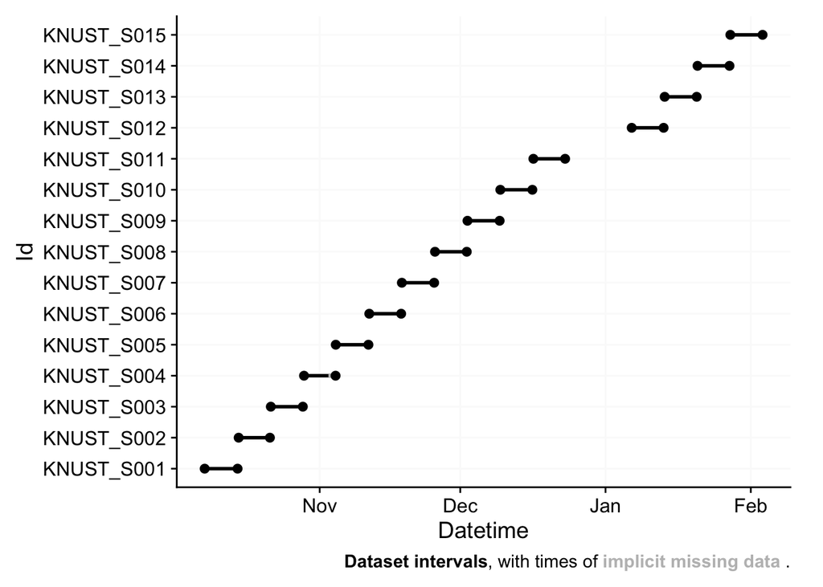

```r
data <- import$ActLumus(files, tzs[site], auto.id = pattern)
```

## Regularizing data

In the first step, we will trim the data by the study time.

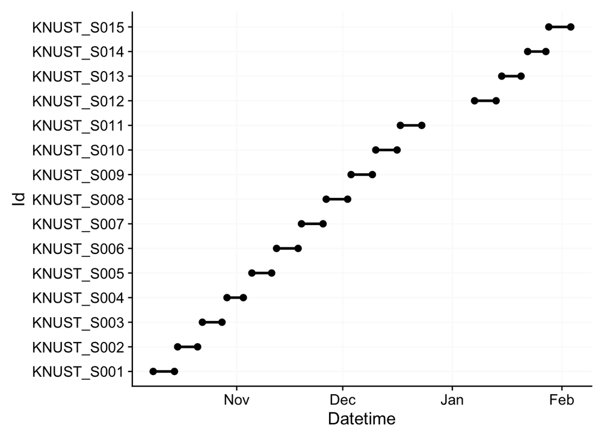

```r
path_study_dates <- paste0("../data/Study_dates_MeLiDos_", site, ".xlsx")

#import table with study times
Study_dates <- read_excel(path_study_dates)
#gather the important information
Study_dates <-
  Study_dates |>
    rename(Id = subjectID_device, start = datetime_trial_start, end = datetime_trial_end) |>
    select(Id, start, end) |>
    mutate(across(c(start, end), \(x) force_tz(x, tzs[site])),
           trial = TRUE) |>
    filter(str_detect(Id, "_h$")) |>
    mutate(Id = str_remove(Id, "_h$")) |>
  group_by(Id)

#add the trim information to the dataset and filter by it
data <-
  data |>
  add_states(Study_dates) |>
  dplyr::filter(trial) |>
  select(-trial)

data |> gg_overview()
```

## Regularizing data

```r
data |> has_gaps()
```

```
[1] TRUE
```

```r
data |> has_irregulars()
```

```
[1] TRUE
```

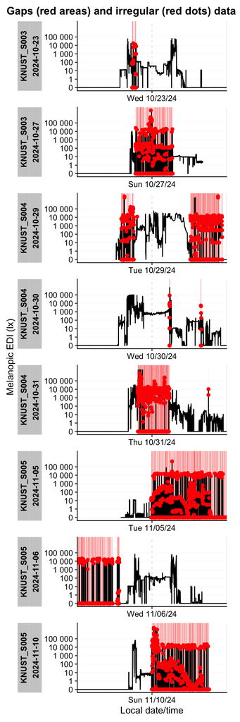

```r
data |> gg_gaps(group.by.days = TRUE, show.irregulars = TRUE, full.days = FALSE)
```

Apparently, `KNUST_S003`, `KNUST_S004`, and `KNUST_S005` suffer from some kind of defect, where the data become irregular and show values around 10^4 lx, even at night. We first bin the irregular data into the next regular interval, and then convert implicit to explicit days. We will further remove unreasonably high values above 100.000 lx melanopic EDI

```r
data_cleaned <-
  data |>
  aggregate_Datetime() |> #remove irregular data
  filter(MEDI <= 10^5) |> #remove high values
  gap_handler(full.days = TRUE) #remove implicit gaps

data_cleaned |> has_gaps() #no more implicit gaps
```

```
[1] FALSE
```

```r
data_cleaned |> has_irregulars() #no more irregular data
```

```
[1] FALSE
```

```r
data_cleaned |> gap_table()
```

Summary of available and missing data

Variable: melanopic EDI

|  | Data Regular Time | Data Regular % | Data Regular n<sup>1</sup> | Data Irregular n<sup>2,1</sup> | Data Range Time | Data Range n<sup>1</sup> | Data Interval Time | Missing Gaps N | Missing Gaps ø | Missing Gaps øn<sup>1</sup> | Missing Gaps Time | Missing Gaps % | Missing Gaps n<sup>1</sup> | Missing Implicit Time | Missing Implicit % | Missing Implicit n<sup>1</sup> | Missing Explicit Time | Missing Explicit % | Missing Explicit n<sup>1</sup> |
| --- | --- | --- | --- | --- | --- | --- | --- | --- | --- | --- | --- | --- | --- | --- | --- | --- | --- | --- | --- |
| **Overall** | 12w 2d 20m 40s | 86.9%<sup>3</sup> | 743,164 | 0 | 14w 1d | 855,360 | 10 | 5,207 | 5d 11h 56m 22s | 47,498 | 1w 5d 23h 39m 20s | 13.1%<sup>3</sup> | 112,196 | 0s | 0.0%<sup>3</sup> | 0 | 1w 5d 23h 39m 20s | 13.1%<sup>3</sup> | 112,196 |
| KNUST_S001 |  |  |  |  |  |  |  |  |  |  |  |  |  |  |  |  |  |  |  |
|  | 6d 23m | 85.9% | 51,978 | 0 | 1w | 60,480 | 10s | 2 | 11h 48m 30s | 4,251 | 23h 37m | 14.1% | 8,502 | 0s | 0.0% | 0 | 23h 37m | 14.1% | 8,502 |
| KNUST_S002 |  |  |  |  |  |  |  |  |  |  |  |  |  |  |  |  |  |  |  |
|  | 5d 15h 22m 50s | 94.0% | 48,737 | 0 | 6d | 51,840 | 10s | 3 | 2h 52m 23s | 1,034 | 8h 37m 10s | 6.0% | 3,103 | 0s | 0.0% | 0 | 8h 37m 10s | 6.0% | 3,103 |
| KNUST_S003 |  |  |  |  |  |  |  |  |  |  |  |  |  |  |  |  |  |  |  |
|  | 5d 12h 57m 40s | 92.3% | 47,866 | 0 | 6d | 51,840 | 10s | 68 | 9m 44s | 58 | 11h 2m 20s | 7.7% | 3,974 | 0s | 0.0% | 0 | 11h 2m 20s | 7.7% | 3,974 |
| KNUST_S004 |  |  |  |  |  |  |  |  |  |  |  |  |  |  |  |  |  |  |  |
|  | 4d 9h 2m 30s | 87.5% | 37,815 | 0 | 5d | 43,200 | 10s | 1882 | 29s | 3 | 14h 57m 30s | 12.5% | 5,385 | 0s | 0.0% | 0 | 14h 57m 30s | 12.5% | 5,385 |
| KNUST_S005 |  |  |  |  |  |  |  |  |  |  |  |  |  |  |  |  |  |  |  |
|  | 5d 4h 44m 30s | 86.6% | 44,907 | 0 | 6d | 51,840 | 10s | 3232 | 21s | 2 | 19h 15m 30s | 13.4% | 6,933 | 0s | 0.0% | 0 | 19h 15m 30s | 13.4% | 6,933 |
| KNUST_S006 |  |  |  |  |  |  |  |  |  |  |  |  |  |  |  |  |  |  |  |
|  | 6d 2h 23m | 87.1% | 52,698 | 0 | 1w | 60,480 | 10s | 2 | 10h 48m 30s | 3,891 | 21h 37m | 12.9% | 7,782 | 0s | 0.0% | 0 | 21h 37m | 12.9% | 7,782 |
| KNUST_S007 |  |  |  |  |  |  |  |  |  |  |  |  |  |  |  |  |  |  |  |
|  | 6d 2h 12m | 87.0% | 52,632 | 0 | 1w | 60,480 | 10s | 2 | 10h 54m | 3,924 | 21h 48m | 13.0% | 7,848 | 0s | 0.0% | 0 | 21h 48m | 13.0% | 7,848 |
| KNUST_S008 |  |  |  |  |  |  |  |  |  |  |  |  |  |  |  |  |  |  |  |
|  | 6d 1h 21m | 86.5% | 52,326 | 0 | 1w | 60,480 | 10s | 2 | 11h 19m 30s | 4,077 | 22h 39m | 13.5% | 8,154 | 0s | 0.0% | 0 | 22h 39m | 13.5% | 8,154 |
| KNUST_S009 |  |  |  |  |  |  |  |  |  |  |  |  |  |  |  |  |  |  |  |
|  | 6d 17m | 85.9% | 51,942 | 0 | 1w | 60,480 | 10s | 2 | 11h 51m 30s | 4,269 | 23h 43m | 14.1% | 8,538 | 0s | 0.0% | 0 | 23h 43m | 14.1% | 8,538 |
| KNUST_S010 |  |  |  |  |  |  |  |  |  |  |  |  |  |  |  |  |  |  |  |
|  | 6d 43m | 86.1% | 52,098 | 0 | 1w | 60,480 | 10s | 2 | 11h 38m 30s | 4,191 | 23h 17m | 13.9% | 8,382 | 0s | 0.0% | 0 | 23h 17m | 13.9% | 8,382 |
| KNUST_S011 |  |  |  |  |  |  |  |  |  |  |  |  |  |  |  |  |  |  |  |
|  | 6d 1h 4m | 86.3% | 52,224 | 0 | 1w | 60,480 | 10s | 2 | 11h 28m | 4,128 | 22h 56m | 13.7% | 8,256 | 0s | 0.0% | 0 | 22h 56m | 13.7% | 8,256 |
| KNUST_S012 |  |  |  |  |  |  |  |  |  |  |  |  |  |  |  |  |  |  |  |
|  | 6d 2h 14m | 87.0% | 52,644 | 0 | 1w | 60,480 | 10s | 2 | 10h 53m | 3,918 | 21h 46m | 13.0% | 7,836 | 0s | 0.0% | 0 | 21h 46m | 13.0% | 7,836 |
| KNUST_S013 |  |  |  |  |  |  |  |  |  |  |  |  |  |  |  |  |  |  |  |
|  | 5d 11h 7m 10s | 78.0% | 47,203 | 0 | 1w | 60,480 | 10s | 2 | 18h 26m 25s | 6,638 | 1d 12h 52m 50s | 22.0% | 13,277 | 0s | 0.0% | 0 | 1d 12h 52m 50s | 22.0% | 13,277 |
| KNUST_S014 |  |  |  |  |  |  |  |  |  |  |  |  |  |  |  |  |  |  |  |
|  | 5d 3h 23m 50s | 85.7% | 44,423 | 0 | 6d | 51,840 | 10s | 2 | 10h 18m 5s | 3,708 | 20h 36m 10s | 14.3% | 7,417 | 0s | 0.0% | 0 | 20h 36m 10s | 14.3% | 7,417 |
| KNUST_S015 |  |  |  |  |  |  |  |  |  |  |  |  |  |  |  |  |  |  |  |
|  | 6d 5h 5m 10s | 88.7% | 53,671 | 0 | 1w | 60,480 | 10s | 2 | 9h 27m 25s | 3,404 | 18h 54m 50s | 11.3% | 6,809 | 0s | 0.0% | 0 | 18h 54m 50s | 11.3% | 6,809 |

<sup>1</sup> Number of (missing or actual) observations  
<sup>2</sup> If n > 0: it is possible that the other summary statistics are affected, as they are calculated based on the most prominent interval.  
<sup>3</sup> Based on times, not necessarily number of observations

# Dealing with measurement spikes

Measurement spikes seem to happen at random during certain periods of time. We can capture those by treating them as clusters of at maximum 2 epochs length. The next step visualizes this approach for `KNUST_S005`.

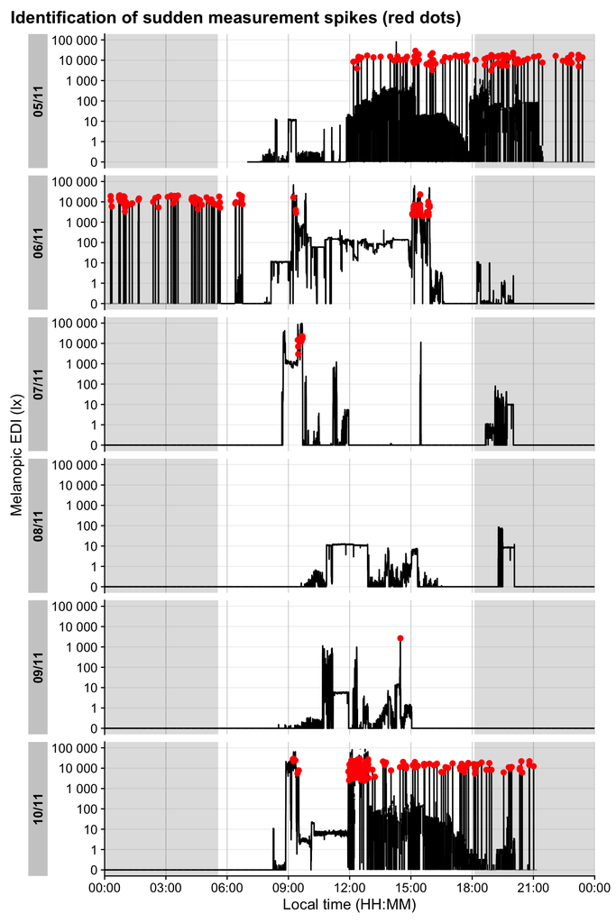

```r
data_cleaned |>
  filter(Id == "KNUST_S005") |>
  add_clusters(
    MEDI > 2000 & MEDI < 30000,
    cluster.duration = "20 secs",
    duration.type = "max"
  ) |>
  gg_day(geom = "line") |>
  gg_photoperiod(coordinates[[site]]) +
  geom_point(data = \(x) filter(x, !is.na(state)), col = "red") +
  labs(title = "Identification of sudden measurement spikes (red dots)")
```

We assess how many there are across the participants:

```r
data_cleaned |>
  extract_clusters(
    MEDI > 2000 & MEDI < 30000,
    cluster.duration = "20 secs",
    duration.type = "max",
    add.label = TRUE
  ) |>
  group_by(label, Id) |>
  summarize_numeric() |>
  select(Id, label, episodes) |>
  group_by(label) |>
  gt() |>
  tab_header("Measurement spikes")
```

Measurement spikes

| Id | episodes |
| --- | --- |
| MEDI>2000&MEDI<30000\|d≤20secs |  |
| KNUST_S001 | 71 |
| KNUST_S002 | 37 |
| KNUST_S003 | 87 |
| KNUST_S004 | 1051 |
| KNUST_S005 | 306 |
| KNUST_S006 | 94 |
| KNUST_S007 | 249 |
| KNUST_S008 | 39 |
| KNUST_S009 | 144 |
| KNUST_S010 | 60 |
| KNUST_S011 | 183 |
| KNUST_S012 | 218 |
| KNUST_S013 | 174 |
| KNUST_S014 | 76 |
| KNUST_S015 | 107 |

Spikes are detected for every Id. We will not remove the data, but rather replace them with the value 2 intervals prior. This ensures plausible values for that time and avoids that a spike is copied over.

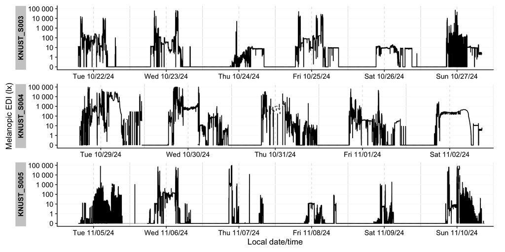

```r
data_cleaned <-
  data_cleaned |>
  add_clusters(
    MEDI > 2000 & MEDI < 30000,
    cluster.duration = "20 secs",
    duration.type = "max"
  ) |>
  mutate(MEDI = ifelse(!is.na(state), lag(MEDI, 2), MEDI))

data_cleaned |>
  filter(Id %in% c("KNUST_S003", "KNUST_S004", "KNUST_S005")) |>
  gg_days()
```

These data now look sensible enough for further visualization and processing.

```r
data_cleaned <-
data |>
  cut_Datetime("10 secs", New.colname = Datetime) |> #remove irregular data
  gap_handler(full.days = TRUE) #remove implicit gaps

data_cleaned |> has_gaps() #no more implicit gaps
```

```
[1] FALSE
```

```r
data_cleaned |> has_irregulars() #no more irregular data
```

```
[1] FALSE
```

```r
data_cleaned |> gap_table(MEDI) |> cols_hide(ends_with("_n"))
```

Summary of available and missing data

Variable: melanopic EDI

|  | Data Regular Time | Data Regular % | Data Irregular n<sup>1,2</sup> | Data Range Time | Data Interval Time | Missing Gaps N | Missing Gaps ø | Missing Gaps Time | Missing Gaps % | Missing Implicit Time | Missing Implicit % | Missing Explicit Time | Missing Explicit % |
| --- | --- | --- | --- | --- | --- | --- | --- | --- | --- | --- | --- | --- | --- |
| **Overall** | 12w 2d 14h 41m | 87.0%<sup>3</sup> | 0 | 14w 1d 13h 59m 30s | 10 | 5,197 | 5d 13h 26m 8s | 1w 5d 23h 18m 30s | 13.0%<sup>3</sup> | 0s | 0.0%<sup>3</sup> | 1w 5d 23h 18m 30s | 13.0%<sup>3</sup> |
| KNUST_S001 |  |  |  |  |  |  |  |  |  |  |  |  |  |
|  | 6d 23m | 85.9% | 0 | 1w | 10s | 2 | 11h 48m 30s | 23h 37m | 14.1% | 0s | 0.0% | 23h 37m | 14.1% |
| KNUST_S002 |  |  |  |  |  |  |  |  |  |  |  |  |  |
|  | 5d 15h 23m | 94.0% | 0 | 6d | 10s | 2 | 4h 18m 30s | 8h 37m | 6.0% | 0s | 0.0% | 8h 37m | 6.0% |
| KNUST_S003 |  |  |  |  |  |  |  |  |  |  |  |  |  |
|  | 5d 13h 3m 10s | 92.4% | 0 | 6d | 10s | 49 | 13m 24s | 10h 56m 50s | 7.6% | 0s | 0.0% | 10h 56m 50s | 7.6% |
| KNUST_S004 |  |  |  |  |  |  |  |  |  |  |  |  |  |
|  | 4d 14h 19m 20s | 88.2% | 0 | 5d 5h 8m | 10s | 1891 | 28s | 14h 48m 40s | 11.8% | 0s | 0.0% | 14h 48m 40s | 11.8% |
| KNUST_S005 |  |  |  |  |  |  |  |  |  |  |  |  |  |
|  | 5d 13h 42m 20s | 87.5% | 0 | 6d 8h 51m 30s | 10s | 3233 | 21s | 19h 9m 10s | 12.5% | 0s | 0.0% | 19h 9m 10s | 12.5% |
| KNUST_S006 |  |  |  |  |  |  |  |  |  |  |  |  |  |
|  | 6d 2h 23m | 87.1% | 0 | 1w | 10s | 2 | 10h 48m 30s | 21h 37m | 12.9% | 0s | 0.0% | 21h 37m | 12.9% |
| KNUST_S007 |  |  |  |  |  |  |  |  |  |  |  |  |  |
|  | 6d 2h 12m | 87.0% | 0 | 1w | 10s | 2 | 10h 54m | 21h 48m | 13.0% | 0s | 0.0% | 21h 48m | 13.0% |
| KNUST_S008 |  |  |  |  |  |  |  |  |  |  |  |  |  |
|  | 6d 1h 21m | 86.5% | 0 | 1w | 10s | 2 | 11h 19m 30s | 22h 39m | 13.5% | 0s | 0.0% | 22h 39m | 13.5% |
| KNUST_S009 |  |  |  |  |  |  |  |  |  |  |  |  |  |
|  | 6d 17m | 85.9% | 0 | 1w | 10s | 2 | 11h 51m 30s | 23h 43m | 14.1% | 0s | 0.0% | 23h 43m | 14.1% |
| KNUST_S010 |  |  |  |  |  |  |  |  |  |  |  |  |  |
|  | 6d 43m | 86.1% | 0 | 1w | 10s | 2 | 11h 38m 30s | 23h 17m | 13.9% | 0s | 0.0% | 23h 17m | 13.9% |
| KNUST_S011 |  |  |  |  |  |  |  |  |  |  |  |  |  |
|  | 6d 1h 4m | 86.3% | 0 | 1w | 10s | 2 | 11h 28m | 22h 56m | 13.7% | 0s | 0.0% | 22h 56m | 13.7% |
| KNUST_S012 |  |  |  |  |  |  |  |  |  |  |  |  |  |
|  | 6d 2h 14m | 87.0% | 0 | 1w | 10s | 2 | 10h 53m | 21h 46m | 13.0% | 0s | 0.0% | 21h 46m | 13.0% |
| KNUST_S013 |  |  |  |  |  |  |  |  |  |  |  |  |  |
|  | 5d 11h 7m 10s | 78.0% | 0 | 1w | 10s | 2 | 18h 26m 25s | 1d 12h 52m 50s | 22.0% | 0s | 0.0% | 1d 12h 52m 50s | 22.0% |
| KNUST_S014 |  |  |  |  |  |  |  |  |  |  |  |  |  |
|  | 5d 3h 23m 50s | 85.7% | 0 | 6d | 10s | 2 | 10h 18m 5s | 20h 36m 10s | 14.3% | 0s | 0.0% | 20h 36m 10s | 14.3% |
| KNUST_S015 |  |  |  |  |  |  |  |  |  |  |  |  |  |
|  | 6d 5h 5m 10s | 88.7% | 0 | 1w | 10s | 2 | 9h 27m 25s | 18h 54m 50s | 11.3% | 0s | 0.0% | 18h 54m 50s | 11.3% |

<sup>1</sup> If n > 0: it is possible that the other summary statistics are affected, as they are calculated based on the most prominent interval.  
<sup>2</sup> Number of (missing or actual) observations  
<sup>3</sup> Based on times, not necessarily number of observations

## Exporting values

```r
light_1min <-
data_cleaned |>
  aggregate_Datetime("1 minute", numeric.handler = \(x) mean(x, na.rm = TRUE)) |>
  remove_partial_data(MEDI, threshold.missing = "3 hours", by.date = TRUE)
```

```
This dataset has irregular or singular data. Singular data will automatically be removed. If you are uncertain about irregular data, you can check them with `gap_finder`, `gap_table`, and `gg_gaps`.
```

```r
light <- data_cleaned

save(light_1min, file = "../data/imported/light/light_1minute.RData")
save(light, file = "../data/imported/light/light.RData")
```

## Visualization

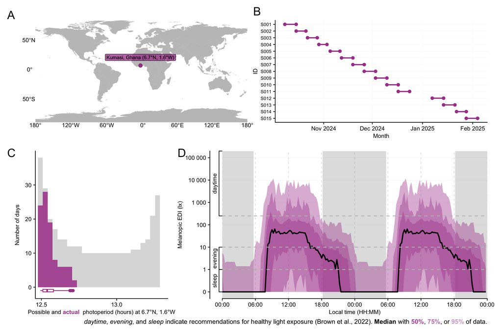

```r
prefix <- paste0(site, "_")

data_cleaned |>
  mutate(Id = Id |> fct_relabel(\(x) str_remove(x, prefix))) |>
grand_overview(coordinates[[site]], cities[[site]], countries[[site]],
               country_colors[[site]])
```

```r
ggsave("../output/figures/Figure_1.png", width = 17, height = 10, scale = 2, units = "cm")
ggsave("../output/figures/Figure_1.jpeg", width = 17, height = 10, scale = 2, units = "cm")
```

## Stats

### Summary table

```r
table_summary <-
summary_table(
  data_cleaned,
  coordinates = coordinates[[site]],
  location = cities[[site]],
  site = countries[[site]],
  color = country_colors[[site]],
  histograms = TRUE
)

table_summary
```

Summary table

Kumasi, Ghana, 6.7°N, 1.6°W, TZ: Africa/Accra

| Overview |  |  |  |  |
| --- | --- | --- | --- | --- |
| Participants | Participants | **15** |  |  |
| Participant-days | Participant-days | **99** (5 - 7) |  |  |
| Days ≥80% complete | Days ≥80% complete | **72** (4 - 5) |  |  |
| Missing/irregular | Missing/Irregular | **13.0%** (6.0% - 22.0%) |  |  |
| Photoperiod | Photoperiod | **12h 33m** (12h 29m - 12h 42m) |  | <sup>1</sup> |
| Metrics<sup>2</sup> |  |  |  |  |
| Dose | D (lx·h) | **11,687** ±16,060 (28 - 92,213) |  |  |
| Duration above 250 lx | TAT<sub>250</sub> | **1h 43m** ±1h 48m (0s - 6h 51m) |  |  |
| Duration within 1-10 lx | TWT<sub>1-10</sub> | **3h 24m** ±2h 36m (13m 50s - 13h 19m) |  |  |
| Duration below 1 lx | TBT<sub>1</sub> | **13h 5s** ±3h 43m (4h 8m - 22h 2m) |  |  |
| Period above 250 lx | PAT<sub>250</sub> | **28m 1s** ±36m 52s (0s - 4h 7m) |  |  |
| Duration above 1000 lx | TAT<sub>1000</sub> | **58m 11s** ±1h 4m (0s - 5h 13m) |  |  |
| First timing above 250 lx | FLiT<sub>250</sub> | **08:58** ±02:05 (00:17 - 15:05) |  | <sup>1</sup> |
| Mean timing above 250 lx | MLiT<sub>250</sub> | **12:08** ±01:34 (08:30 - 15:55) |  | <sup>1</sup> |
| Last timing above 250 lx | LLiT<sub>250</sub> | **16:24** ±02:46 (08:53 - 23:16) |  | <sup>1</sup> |
| Brightest 10h midpoint | M10<sub>midpoint</sub> | **13:10** ±01:56 (04:59 - 18:59) |  | <sup>1</sup> |
| Darkest 5h midpoint | L5<sub>midpoint</sub> | **03:16** ±03:24 (02:29 - 22:24) |  | <sup>1</sup> |
| Brightest 10h mean<sup>3</sup> | M10<sub>mean</sub> (lx) | **66.3** ±90.8 (0.1 - 372.7) |  |  |
| Darkest 5h mean<sup>3</sup> | L5<sub>mean</sub> (lx) | **0.0** ±0.0 (0.0 - 0.2) |  |  |
| Interdaily stability | IS | **0.276** ±0.059 (0.186 - 0.356) |  |  |
| Intradaily variability | IV | **1.420** ±0.396 (0.619 - 2.043) |  |  |

values show: **mean** ±sd (min - max) and are all based on measurements of melanopic EDI (lx)  
<sup>1</sup> Histogram limits are set from 00:00 to 24:00  
<sup>2</sup> Metrics are calculated on a by-participant-day basis (n=72) with the exception of IV and IS, which are calculated on a by-participant basis (n=15).  
<sup>3</sup> Values were log 10 transformed prior to averaging, with an offset of 0.1, and backtransformed afterwards

```r
gtsave(table_summary, here("output/tables/table_summary.png"), vwidth = 850, expand = 30)
gtsave(table_summary, here("output/tables/table_summary.pdf"))
gtsave(table_summary |> cols_hide(c(plot)), here("output/tables/table_summary.docx"))
```